# EmpatIA 2026 · kit de prensa

El Índice EmpatIA y el bloque de inteligencia artificial, con cada cifra lista para citar

Todas las cifras de este kit vienen con **su base y su margen**. Dos grupos cuyos rangos se pisan no son distintos, por grande que parezca la diferencia entre sus porcentajes. Cada ángulo arranca con **la pregunta textual del cuestionario** que lo produce, para que ninguna cifra se cite sin saber qué se preguntó. Al final hay una ficha técnica y una sección sobre qué **no** dice este estudio.

Donde se pudo, cada cifra trae además **cuánto se movió desde 2025**.

# Lo esencial

10,8de 100 es el Índice EmpatIA promedio de las marcas: cuánto se las asocia, en promedio, con cercanía y con tecnología entre quienes las conocenPromedio de 115 marcas · ±0,6 puntos

P18 ¿Has oído hablar de alguno de estos asistentes conversacionales de Inteligencia Artificial, aunque sólo sea de nombre?

P19 Y aproximadamente, ¿Qué tanto utilizas estos asistentes?

P23 Y cuando necesitas resolver un problema, por ejemplo, reclamar por un cobro que no corresponde, ¿Qué canal prefieres?

P25 Pensando en el uso que le das a la Inteligencia Artificial ¿Has usado alguna vez un asistente o agente de Inteligencia Artificial para realizar alguna de las siguientes tareas?

P27 Para terminar, ¿Qué prefieres? Una marca que…

70%de las personas usa algún asistente de inteligencia artificial al menos un par de veces al mesP18 + P19 · ±2,4 puntos · ▲ 19 puntos desde 2025

36%lo usa todos los días: para esa parte del país la inteligencia artificial ya es rutina, no una pruebaP18 + P19 · ±2,5 puntos · ▲ 16 puntos desde 2025

82%le ha pedido a una IA que busque, recomiende o compare antes de comprarP25 · ±2,0 puntos

43%ya dejó que una IA hiciera algo por ella: agendar, pagar, reclamar o comprarP25 · ±2,5 puntos

79%prefiere que lo atienda una persona cuando tiene que resolver un problemaP23 · ±2,1 puntos · ▼ 4 puntos desde 2025

66%elige una marca menos personalizada a cambio de que proteja sus datosP27 · ±2,4 puntos

# El Índice EmpatIA promedio

El Índice EmpatIA de una marca mide, entre quienes la conocen, cuánto se la asocia con cercanía y con tecnología, en una escala de 0 a 100. El promedio toma las 115 marcas del ranking 2026 y cuenta a cada una una vez, sea muy o poco conocida.

En 2026 el promedio es **10,8** y se mantiene respecto de 2025; en 2023 era 11,5, y la diferencia con ese año también queda dentro del margen.

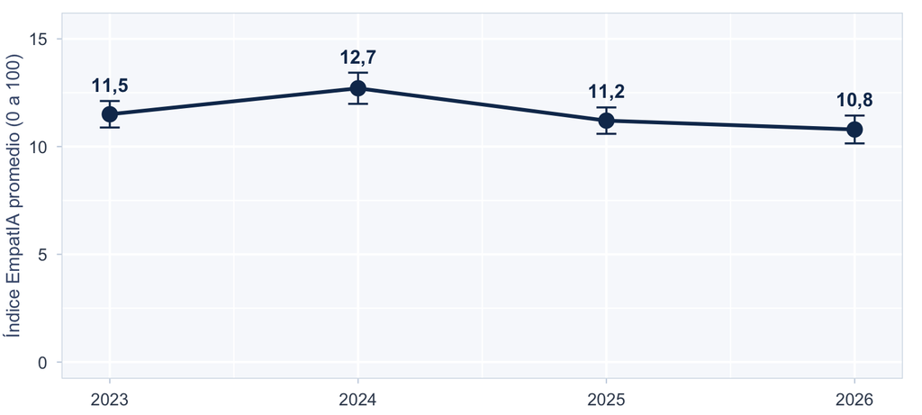

«En 2026, el Índice EmpatIA promedio de las marcas del estudio es de 10,8 sobre 100».

Es un promedio de marcas, no de personas: una marca de nicho pesa lo mismo que una masiva. Cada edición promedia las marcas de su propio ranking (113 en 2023, 110 en 2024, 117 en 2025, 115 en 2026), así que una parte de cualquier cambio puede venir de las marcas que entran o salen del listado. Un cambio dentro de ±0,6 puntos no se puede atribuir al mercado.

# La adopción se disparó en un año

P18 ¿Has oído hablar de alguno de estos asistentes conversacionales de Inteligencia Artificial, aunque sólo sea de nombre?

P19 Y aproximadamente, ¿Qué tanto utilizas estos asistentes?

P20 En una escala del 1 a 5, donde 1 es “Nada preocupado” y 5 es “Muy preocupado” ¿Qué tan preocupado(a) te sientes frente a los siguientes posibles impactos del uso de la inteligencia artificial?

P21 Cuando necesitas un servicio de una marca, como por ejemplo cambiar una clave o consultar información, ¿Cuál de las siguientes alternativas representa mejor lo que prefieres hacer?

P23 Y cuando necesitas resolver un problema, por ejemplo, reclamar por un cobro que no corresponde, ¿Qué canal prefieres?

Cada barra de abajo es **un indicador, no una pregunta suelta**, y el gráfico dice de qué pregunta sale cada uno. El titular de adopción es un cruce de dos: **P18** pregunta qué asistentes conoce la persona y **P19**, con qué frecuencia usa cada uno de los que conoce. Se cuenta a la persona y no al asistente —quien usa tres sigue siendo una persona— y se le llama usuaria cuando declara usar alguno al menos un par de veces al mes. El resto de los indicadores viene de una sola pregunta, salvo los dos que combinan trámite y problema (P21 y P23) o uso y preocupación (P20).

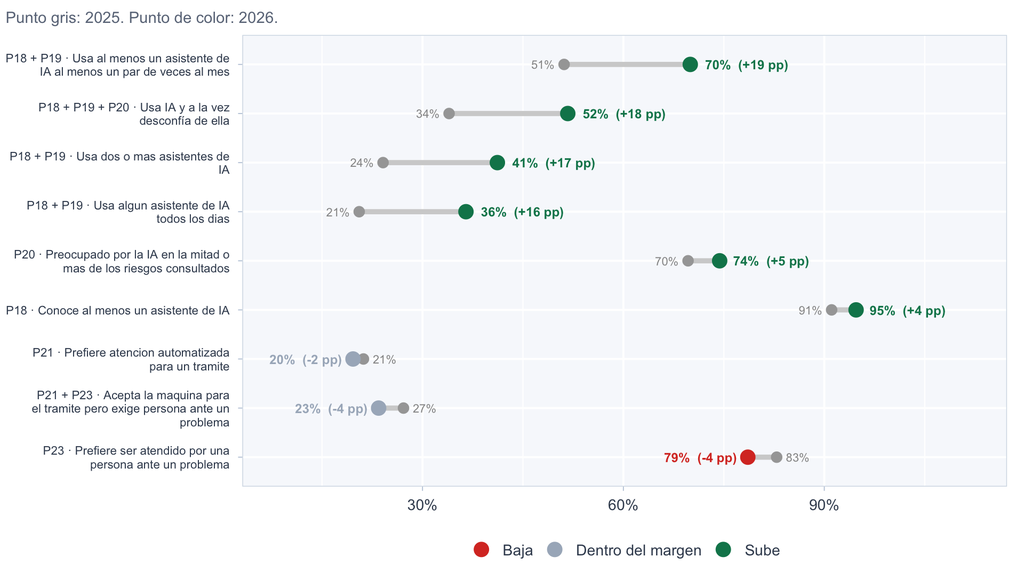

«El uso de asistentes de inteligencia artificial en Chile pasó del 51% al 70% en un año. Hoy la mayoría de las personas usa alguno al menos un par de veces al mes, y el 36% lo usa todos los días: 21% el año pasado».

De 9 indicadores comparables, **7 se movieron por sobre su margen**. Ningún otro bloque del estudio EmpatIA —expectativas sobre las marcas, actitudes hacia los sistemas automatizados— se mueve a esta velocidad: ahí 1 de 21 indicadores supera el margen.

| Grupo | % | Rango | Casos |
| --- | --- | --- | --- |
| 18 a 24 | 94 | 90 – 97 | 221 |
| 25 a 34 | 82 | 77 – 86 | 300 |
| 35 a 44 | 73 | 68 – 78 | 289 |
| 45 a 54 | 58 | 52 – 63 | 297 |
| 55 a 64 | 50 | 44 – 57 | 240 |
| 65 a 75 | 40 | 33 – 46 | 209 |

«Usa» significa aquí **al menos un par de veces al mes**, no haber probado alguna vez. Es un umbral de uso incorporado, y por eso la cifra es más baja que la de «ha usado alguna vez» que suelen reportar otros estudios.

# Conocer no es usar

P18 ¿Has oído hablar de alguno de estos asistentes conversacionales de Inteligencia Artificial, aunque sólo sea de nombre?

P19 Y aproximadamente, ¿Qué tanto utilizas estos asistentes?

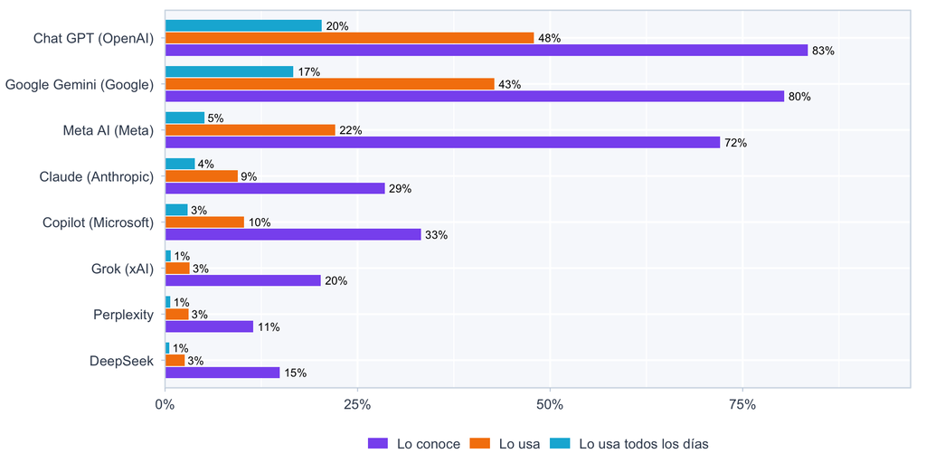

«Chat GPT (OpenAI) es el asistente más usado del país: lo conoce el 83% de las personas y lo usa al menos un par de veces al mes el 48%. La distancia más grande entre conocer y usar la tiene Meta AI (Meta), con 50 puntos».

Las dos barras se leen **sobre la población total**. La frecuencia de uso solo se le pregunta a quien declara conocer el asistente, así que existe una segunda lectura —de cada cien que lo conocen, cuántos lo usan— que da cifras más altas. Está en la columna `usa_entre_conocedores_pct` del archivo de datos, y **no** es intercambiable con esta.

## Todos los días, marca por marca

P19 Y aproximadamente, ¿Qué tanto utilizas estos asistentes?

El uso diario es el peldaño más alto de P19 —«lo uso aproximadamente todos los días»— y el que separa a quien probó la herramienta de quien la incorporó.

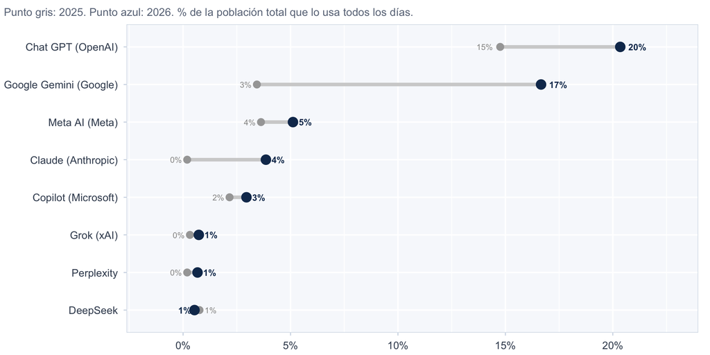

«El uso diario ya no es marginal: el 20% de las personas usa Chat GPT (OpenAI) todos los días, contra el 15% de 2025. El que más creció es Google Gemini (Google): de 3% a 17%».

De los 8 asistentes medidos en las dos ediciones, **3 crecieron en uso diario por sobre el margen**: Chat GPT (OpenAI), Google Gemini (Google) y Claude (Anthropic). En el resto, la diferencia con 2025 cabe dentro del margen.

Estas cifras se leen **sobre la población total**, no sobre quienes conocen el asistente ni sobre quienes lo usan. Decir «el 20% usa Chat GPT (OpenAI) a diario» es correcto; decir «el 20% de sus usuarios» no lo es.

# La escalera de delegación: consejo sí, billetera no

Es la pregunta más reveladora del bloque. No mide actitudes hacia la inteligencia artificial: mide **qué le han dejado hacer**.

P25 Pensando en el uso que le das a la Inteligencia Artificial ¿Has usado alguna vez un asistente o agente de Inteligencia Artificial para realizar alguna de las siguientes tareas?

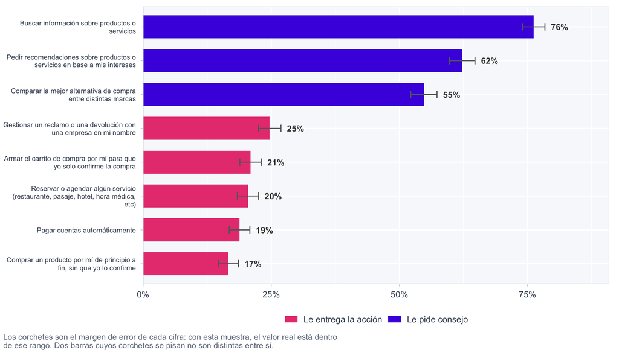

«Las personas ya le piden consejo a la inteligencia artificial: el 76% la ha usado para «buscar información sobre productos o servicios» y el 55% para «comparar la mejor alternativa de compra entre distintas marcas». Pero cuando se trata de que la IA actúe en su nombre, la cifra se desploma: solo el 25% la ha usado para «gestionar un reclamo o una devolución con una empresa en mi nombre», y apenas el 17% para «comprar un producto por mí de principio a fin, sin que yo lo confirme»».

El quiebre no está en la dificultad de la tarea: está en **quién decide**. Todo lo que la IA hace *para* la persona tiene demanda; todo lo que la IA hace *por* la persona, mucha menos.

| Tipo de tarea | % que ha llegado ahí | Rango | Casos |
| --- | --- | --- | --- |
| Le entrega la acción | 43 | 40 – 45 | 1556 |
| Le pide consejo | 82 | 80 – 84 | 1556 |

## La brecha generacional se cierra al subir la escalera

P25 Pensando en el uso que le das a la Inteligencia Artificial ¿Has usado alguna vez un asistente o agente de Inteligencia Artificial para realizar alguna de las siguientes tareas?

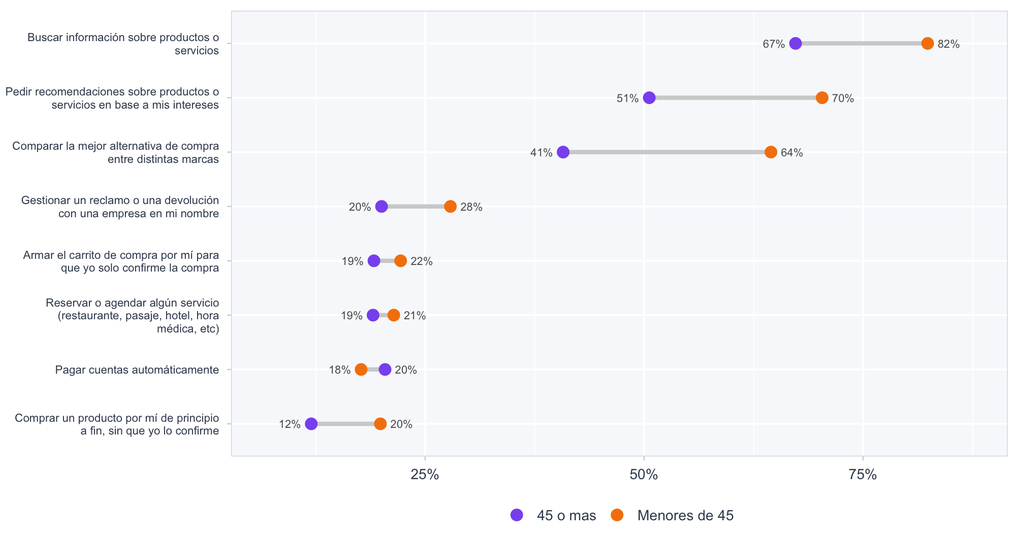

«La brecha entre generaciones no es pareja a lo largo de la escalera: en «comparar la mejor alternativa de compra entre distintas marcas», los menores de 45 le sacan 24 puntos a las personas de 45 o más. Cuando la inteligencia artificial actúa en nombre de la persona, la distancia entre generaciones no pasa de 8 puntos».

Esto **no** significa que los mayores deleguen más que los jóvenes. Significa que en las tareas de acción ambos grupos delegan poco y de forma parecida: son cifras bajas en los dos casos.

## En qué rubros

P26 En la pregunta anterior nos comentaste que has usado agentes de Inteligencia Artificial para algunas gestiones del día a día ¿En cuál o cuáles de las siguientes categorías lo has hecho?

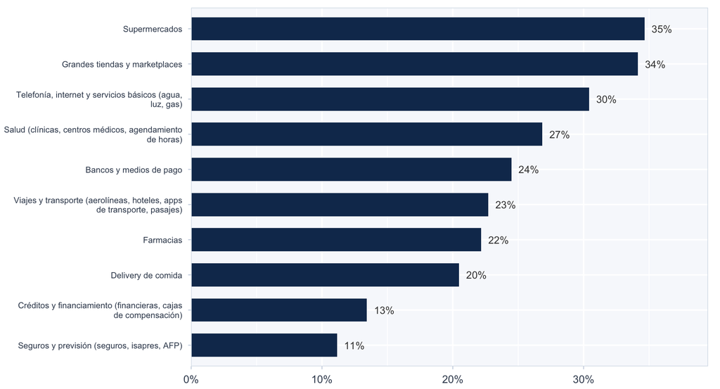

Estas cifras se calculan **solo sobre quienes ya usaron un agente de IA para alguna gestión** (1.271 personas), no sobre la población total. Citarlas como «el 35% de los chilenos» sería un error: es el 35% de quienes ya delegan.

# La paciencia con la máquina se acaba cuando hay un problema

P21 Cuando necesitas un servicio de una marca, como por ejemplo cambiar una clave o consultar información, ¿Cuál de las siguientes alternativas representa mejor lo que prefieres hacer?

P23 Y cuando necesitas resolver un problema, por ejemplo, reclamar por un cobro que no corresponde, ¿Qué canal prefieres?

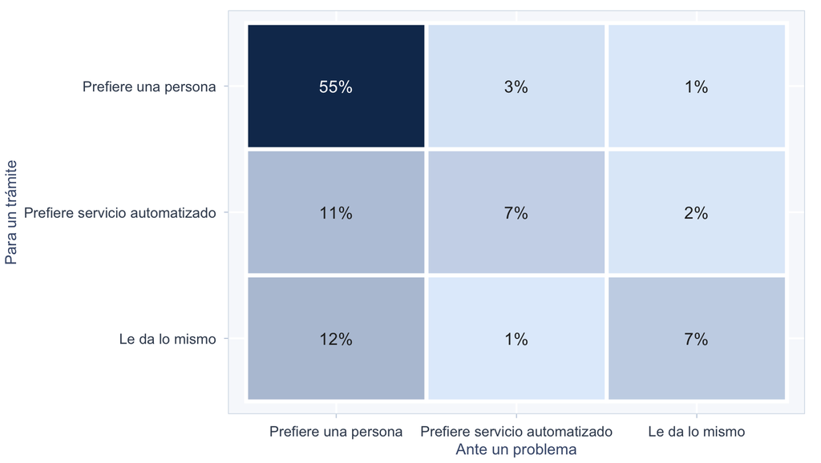

«Es la misma persona contestando dos veces. El 20% acepta un canal automatizado para un trámite como cambiar una clave, pero el 79% exige una persona cuando hay que reclamar por un cobro. El 23% cambia de canal entre una situación y la otra».

## Y vuelve al teléfono

P22 ¿Y qué canal de comunicación es el que prefiere para hacer ese contacto?

P24 ¿Y qué canal de comunicación es el que prefiere para hacer ese contacto?

Las dos preguntas están redactadas igual porque son la misma pregunta hecha dos veces: **P22** viene después del trámite de P21 y **P24**, después del problema de P23. Por eso la comparación es limpia —cambia la situación, no la pregunta—.

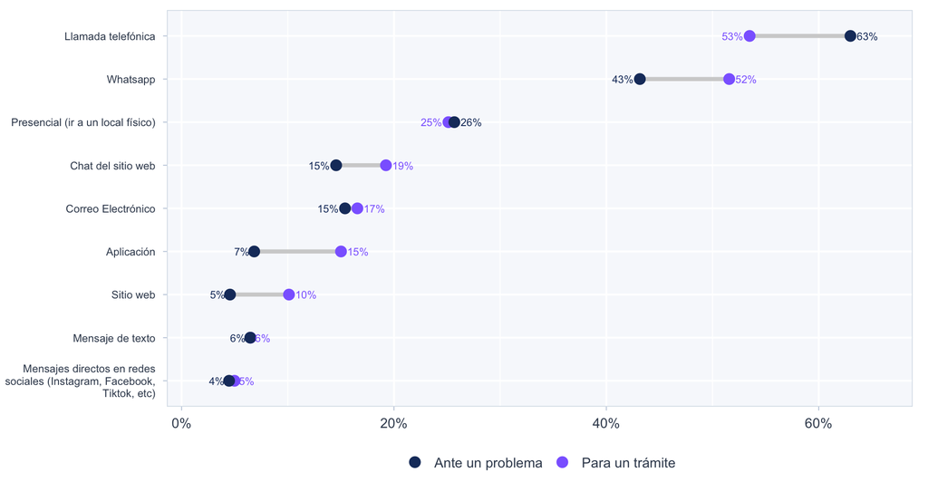

«Cuando aparece un problema, las personas vuelven al canal más antiguo. Llamada telefónica gana 9 puntos de preferencia respecto de un trámite corriente; Whatsapp pierde 8. Lo digital sirve para gestionar; lo humano, para responder».

# Quien usa inteligencia artificial le pide otra cosa al servicio al cliente

El estudio le pregunta a la misma persona dos cosas: **qué asistentes usa** (P18 y P19) y **cómo quiere que la atienda una marca** (P21, P23, P20 y P27). Con eso se puede partir al país en dos —quienes usan algún asistente al menos un par de veces al mes y quienes no— y mirar exactamente la misma pregunta en los dos grupos. Eso es lo que muestra el gráfico: cada línea es una exigencia, y los dos puntos son el mismo porcentaje calculado en cada grupo. Cuanto más larga la línea, más distinto contesta quien usa IA.

P18 ¿Has oído hablar de alguno de estos asistentes conversacionales de Inteligencia Artificial, aunque sólo sea de nombre?

P19 Y aproximadamente, ¿Qué tanto utilizas estos asistentes?

P21 Cuando necesitas un servicio de una marca, como por ejemplo cambiar una clave o consultar información, ¿Cuál de las siguientes alternativas representa mejor lo que prefieres hacer?

P23 Y cuando necesitas resolver un problema, por ejemplo, reclamar por un cobro que no corresponde, ¿Qué canal prefieres?

P20 En una escala del 1 a 5, donde 1 es “Nada preocupado” y 5 es “Muy preocupado” ¿Qué tan preocupado(a) te sientes frente a los siguientes posibles impactos del uso de la inteligencia artificial?

P27 Para terminar, ¿Qué prefieres? Una marca que…

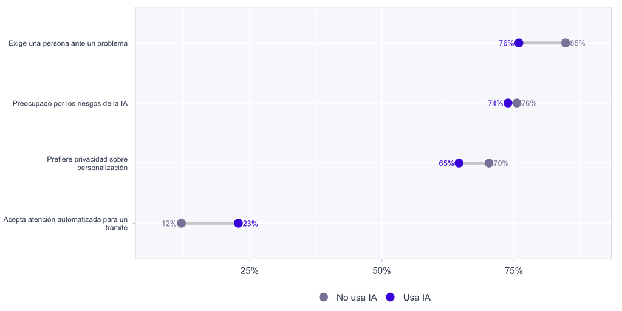

«Quien usa inteligencia artificial le exige cosas distintas a las marcas. En «acepta atención automatizada para un trámite», los usuarios están 11 puntos por encima de quienes no la usan: 23% contra 12%».

De 4 exigencias medidas, **2** distinguen de verdad a quien usa IA de quien no; el resto cabe dentro del margen. Una por una, las que se sostienen:

- **Acepta atención automatizada para un trámite**: 23% entre quienes usan IA y 12% entre quienes no la usan, 11 puntos más.
- **Exige una persona ante un problema**: 76% entre quienes usan IA y 85% entre quienes no la usan, 9 puntos menos.

Puesto en una frase: **quien usa inteligencia artificial pide menos atención humana**. No es que le dé lo mismo —incluso entre quienes la usan, exigir una persona ante un problema sigue siendo mayoritario—, es que el piso de tolerancia a lo automatizado es otro. Para una marca eso significa que el público que más rápido está creciendo es también el que menos castiga un canal automatizado, siempre que resuelva.

Esta es una **asociación, no una causa**. Quien usa IA y quien no usa IA se diferencian también en edad y en otras cosas, y este cruce no las descuenta. No se puede decir que usar IA *vuelva* a la gente más tolerante con los bots: puede ser al revés, o puede ser la edad detrás de las dos cosas. Lo que el estudio sostiene es que los dos rasgos van juntos.

# Entre personalización y privacidad, gana la privacidad

P27 Para terminar, ¿Qué prefieres? Una marca que…

| Grupo | % | Rango | Casos |
| --- | --- | --- | --- |
| 18 a 24 | 66 | 59 – 72 | 221 |
| 25 a 34 | 65 | 60 – 71 | 300 |
| 35 a 44 | 67 | 62 – 73 | 289 |
| 45 a 54 | 68 | 63 – 73 | 297 |
| 55 a 64 | 65 | 59 – 71 | 240 |
| 65 a 75 | 68 | 61 – 74 | 209 |

«Puesta a elegir entre una marca que personaliza usando sus datos y otra que personaliza menos pero los protege, el 66% de las personas elige la segunda. La preferencia no se quiebra por edad: ningún tramo se inclina por la personalización».

# Usar y desconfiar no son opuestos

P18 ¿Has oído hablar de alguno de estos asistentes conversacionales de Inteligencia Artificial, aunque sólo sea de nombre?

P19 Y aproximadamente, ¿Qué tanto utilizas estos asistentes?

P20 En una escala del 1 a 5, donde 1 es “Nada preocupado” y 5 es “Muy preocupado” ¿Qué tan preocupado(a) te sientes frente a los siguientes posibles impactos del uso de la inteligencia artificial?

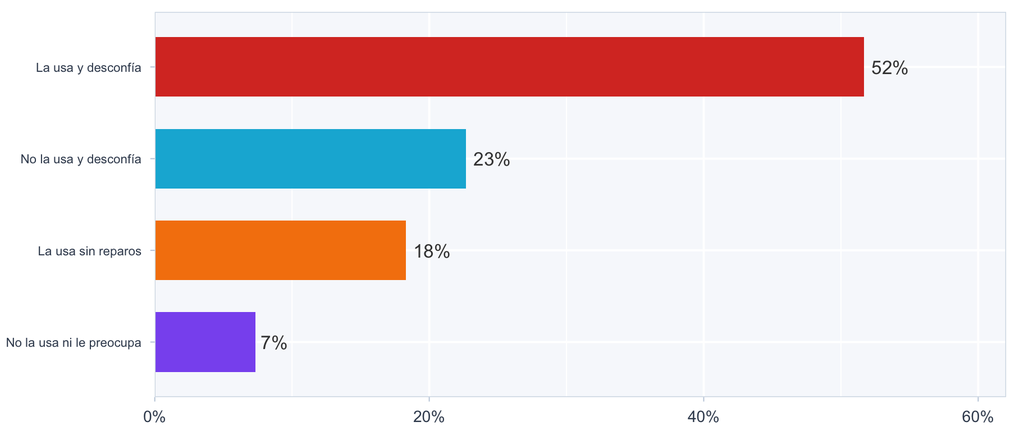

«El grupo más numeroso del país no es el que abraza la inteligencia artificial ni el que la rechaza: es el que hace las dos cosas. El 52% la usa y desconfía».

Se considera preocupada a la persona que declara inquietud alta en **la mitad o más** de los riesgos consultados, no en uno solo. Con un umbral de un solo riesgo la cifra sería mucho más alta y diría mucho menos.

# El costo ambiental

El cuestionario dedica cinco frases al costo ambiental de la inteligencia artificial, y el kit las publica todas: sueltas se pueden citar en cualquier dirección, juntas dicen algo más útil. Dos miden el diagnóstico —cuánto consume y si el problema está exagerado— y las otras miden qué está dispuesta a resignar la persona: plata, velocidad o nada. Todas se responden en una escala de 1 a 5; lo que se grafica es el porcentaje que marca 4 o 5, es decir, que está de acuerdo.

P17 En una escala de 1 a 5 donde 1 es muy en desacuerdo y 5 es muy de acuerdo, ¿Cuán de acuerdo estás con las siguientes afirmaciones relativas a tu experiencia con sistemas de servicio al cliente?

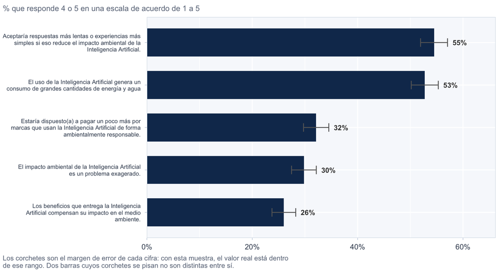

«El 53% cree que la inteligencia artificial consume grandes cantidades de energía y agua, y el 30% cree que su impacto ambiental está exagerado. Un 18% sostiene las dos cosas a la vez, lo que dice menos sobre la contradicción de las personas que sobre lo poco formada que está todavía la opinión en esta materia».

«El 55% aceptaría respuestas más lentas o experiencias más simples si eso reduce el impacto ambiental de la inteligencia artificial, y el 32% pagaría un poco más por marcas que la usan de forma ambientalmente responsable».

**Resignar tiempo cuesta menos que resignar plata**. El 26% cree que los beneficios de la inteligencia artificial compensan su impacto ambiental. Para una marca, el espacio está en la espera más que en el precio: hay más gente dispuesta a esperar que a pagar.

# Lo que esto le pide a las marcas

El estudio mide tres atributos de **IA responsable** para cada marca: «proteja mis datos cuando utiliza inteligencia artificial», «use la inteligencia artificial sin perder autenticidad en su forma de comunicarse» y «use la inteligencia artificial sin perder el trato humano». Funciona distinto al resto del kit. Aquí no se le pregunta a la persona por la inteligencia artificial en general, sino por marcas concretas: a cada una le presentan marcas que conoce y marca cuáles asocia con cada atributo. La cifra es entonces **de cada cien marcas conocidas, en cuántas la persona reconoce el atributo**.

P12 A continuación, piensa a qué marcas asocias cada una de estas frases haciendo click en la(s) marca(s) correspondiente(s)

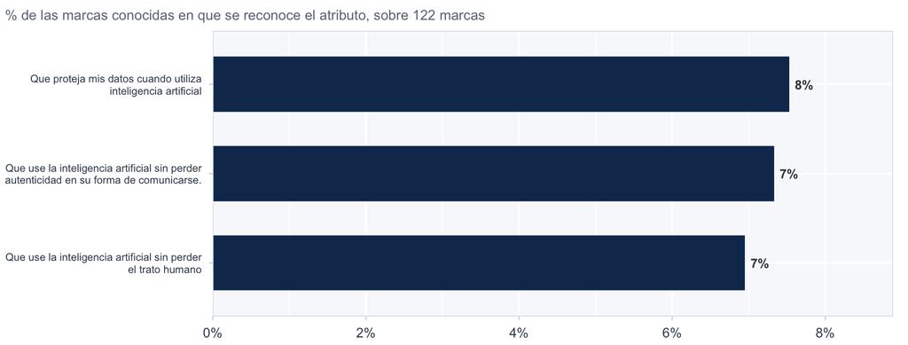

«En promedio, las personas reconocen que una marca «proteja mis datos cuando utiliza inteligencia artificial» en apenas 8 de cada cien marcas que conocen, y que «use la inteligencia artificial sin perder el trato humano» en 7. La marca mejor evaluada en estos atributos, Compraqui, llega a 20 de cada cien personas que la conocen».

Los tres atributos se mueven en la misma franja angosta, entre el 7% y el 8%. Dicho de otra forma: **el atributo está vacante**. Ninguna marca del ranking llega a un cuarto de quienes la conocen, y esa es la oportunidad que abre este bloque.

## Y se lo exige más quien pide una persona

P12 A continuación, piensa a qué marcas asocias cada una de estas frases haciendo click en la(s) marca(s) correspondiente(s)

P23 Y cuando necesitas resolver un problema, por ejemplo, reclamar por un cobro que no corresponde, ¿Qué canal prefieres?

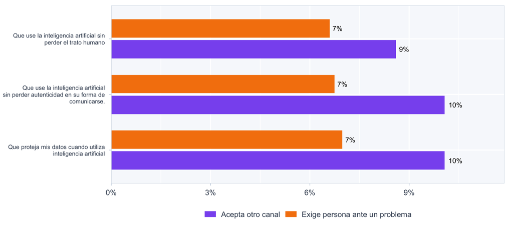

La apertura agrega el dato accionable: quien **exige una persona ante un problema** le reconoce estos atributos a **menos** marcas que quien acepta otro canal. En el atributo «Que use la inteligencia artificial sin perder autenticidad en su forma de comunicarse» la distancia es de 3,3 puntos: 7% contra 10%. Es el público más exigente y el más difícil de convencer, y es mayoritario: el 79% del país pide una persona cuando tiene que reclamar.

Estas cifras **no son porcentajes de personas**: son el promedio, entre marcas, de la proporción de quienes las conocen que les asocia el atributo. No se pueden citar como «el 8% de los chilenos cree que las marcas…». El ranking marca por marca, que es donde esta medición se vuelve comparable, está en el informe del estudio.

# Las diferencias más grandes del estudio

Para una nota, la distancia entre dos grupos suele ser más interesante que el total. Estas son las mayores, ya filtradas: **solo aparecen las que superan el margen conjunto de los dos grupos comparados**. Como cada fila viene de un ángulo distinto, la pregunta que la produce va en su propia columna; el texto completo de cada una está en el ángulo correspondiente, más arriba.

| Indicador | Pregunta | Corte | Más alto | Más bajo | Brecha |
| --- | --- | --- | --- | --- | --- |
| Usa al menos un asistente de IA al menos un par… | P18 + P19 | Tramo de edad | 18 a 24 (94%) | 65 a 75 (40%) | 54 pp |
| Usa IA y a la vez desconfía de ella | P18 + P19 + P20 | Tramo de edad | 18 a 24 (71%) | 65 a 75 (26%) | 45 pp |
| Ha usado IA para: Comparar la mejor alternativa… | P25 | Tramo de edad | 18 a 24 (72%) | 65 a 75 (30%) | 43 pp |
| Usa algun asistente de IA todos los dias | P18 + P19 | Tramo de edad | 18 a 24 (56%) | 65 a 75 (15%) | 41 pp |
| Usa dos o mas asistentes de IA | P18 + P19 | Tramo de edad | 18 a 24 (55%) | 65 a 75 (22%) | 33 pp |
| Ha usado IA para: Pedir recomendaciones sobre p… | P25 | Tramo de edad | 18 a 24 (75%) | 65 a 75 (43%) | 32 pp |
| Usa al menos un asistente de IA al menos un par… | P18 + P19 | Generacion | Menores de 45 (83%) | 45 o mas (51%) | 32 pp |
| Ha delegado en IA alguna tarea del tipo «Le pid… | P25 | Tramo de edad | 18 a 24 (94%) | 65 a 75 (62%) | 32 pp |
| Cree que la IA consume mucha energia y agua | P17 | Tramo de edad | 18 a 24 (67%) | 55 a 64 (41%) | 26 pp |
| Ha usado IA para: Buscar información sobre prod… | P25 | Tramo de edad | 18 a 24 (85%) | 65 a 75 (59%) | 25 pp |
| Pagaria mas por marcas que usan la IA de forma … | P17 | Tramo de edad | 18 a 24 (45%) | 65 a 75 (20%) | 25 pp |
| Usa algun asistente de IA todos los dias | P18 + P19 | Generacion | Menores de 45 (47%) | 45 o mas (22%) | 25 pp |

# Qué NO dice este estudio

- **No mide comportamiento, mide declaración.** Todo lo anterior es lo que las personas dicen que hacen y prefieren. Es lo que una encuesta puede medir, y no es lo mismo que observar la conducta.
- **No establece causas.** Los cruces de este kit muestran que dos cosas van juntas, no que una produzca la otra.
- **No cubre a toda la población.** La muestra es de personas de 18 a 75 años con acceso a internet. Quien no está en línea no está aquí, y para un tema como este esa exclusión no es neutral.
- **Dos puntos no son una tendencia.** El bloque se mide desde 2025. Se puede decir cuánto cambió entre dos mediciones; no hacia dónde va.
- **Las diferencias pequeñas no son diferencias.** Cada cifra trae su rango. Si dos rangos se pisan, el estudio no sostiene que los grupos sean distintos.

# Ficha técnica

**Estudio EmpatIA 2026**, de dobleA y Better Brands. Estudio anual sobre cómo las marcas equilibran humanidad y tecnología para conectar con las personas en Chile.

- Encuesta online a **1.556 personas** de 18 a 75 años, residentes en todas las regiones de Chile.
- Resultados **ponderados** por sexo, tramo de edad, grupo socioeconómico y región, de modo que la muestra reproduzca la composición del país. Tamaño efectivo de muestra: **1.455 casos**, equivalente a un margen de **±2,6 puntos** en el peor caso para el total.
- Los márgenes se calculan sobre **casos efectivos**, que descuentan lo que cuesta ponderar. Usar los casos a secas declararía una precisión que la ponderación ya gastó.
- Las cifras completas, abiertas por género, generación, GSE y tramo de edad, están en `tablas/kpis_ia_prensa.csv`. La escalera de delegación, los rubros, los canales, los cruces por uso, las brechas y la evolución tienen cada uno su propio archivo en la misma carpeta. El Índice EmpatIA promedio y su serie están en `tablas/indice_promedio_serie.csv`.

**Atribución sugerida:** «Estudio EmpatIA 2026, de dobleA y Better Brands».

**Consultas:** contacto@dobleachile.cl · contacto@betterbrands.cl